# R Notebook

# unsupervised method to perfrom anomaly detection

fraud can be seen as anomaly of our data distribution of genuine transactions. unsupervised method can be used to identify anomaly by fitting various model only on genuine transactions and then use a score for each point to detect the goodness of the fitted model given the point.

In particular we can use the distance from the nearest cluster if we use kmeans, or the posterior probability if we use a mixture of gaussian

```r
rm(list = ls())

library(ggpubr)
library(yardstick)
library(corrplot)
library(ggplot2)
library(caret)
library(e1071)
library(tidyverse)

source("metrics.R")

set.seed(42)
```

```r
data = data.frame(readRDS("data_transformed.rds"))
# add a target factor
data$target = factor(data$TX_FRAUD, labels = c("no", "yes"))
head(data)
```

|  | TRANSACTION_ID | TX_DATETIME | CUSTOMER_ID | TERMINAL_ID | TX_AMOUNT | TX_FRAUD | n_tx_1 | n_tx_7 | n_tx_30 | avg_tx_1 | avg_tx_7 | avg_tx_30 | n_tx_terminal_1 | n_tx_terminal_7 | n_tx_terminal_30 | n_fraud_terminal_1 | n_fraud_terminal_7 | n_fraud_terminal_30 | tx_terminal_risk_1 | tx_terminal_risk_7 | tx_terminal_risk_30 | tx_weekend | tx_night | target |
| --- | --- | --- | --- | --- | --- | --- | --- | --- | --- | --- | --- | --- | --- | --- | --- | --- | --- | --- | --- | --- | --- | --- | --- | --- |
| 1 | 288062 | 2018-05-01 00:01:21 | 3546 | 2944 | 18.71 | 0 | 1 | 1 | 1 | 18.71 | 18.71 | 18.71 | 0 | 0 | 0 | 0 | 0 | 0 | 0 | 0 | 0 | 0 | 1 | no |
| 2 | 288063 | 2018-05-01 00:01:48 | 206 | 3521 | 18.60 | 0 | 1 | 1 | 1 | 18.60 | 18.60 | 18.60 | 0 | 0 | 0 | 0 | 0 | 0 | 0 | 0 | 0 | 0 | 1 | no |
| 3 | 288064 | 2018-05-01 00:02:22 | 2610 | 4470 | 66.67 | 0 | 1 | 1 | 1 | 66.67 | 66.67 | 66.67 | 0 | 0 | 0 | 0 | 0 | 0 | 0 | 0 | 0 | 0 | 1 | no |
| 4 | 288065 | 2018-05-01 00:03:15 | 4578 | 1520 | 79.41 | 0 | 1 | 1 | 1 | 79.41 | 79.41 | 79.41 | 0 | 0 | 0 | 0 | 0 | 0 | 0 | 0 | 0 | 0 | 1 | no |
| 5 | 288066 | 2018-05-01 00:03:51 | 1246 | 7809 | 52.08 | 0 | 1 | 1 | 1 | 52.08 | 52.08 | 52.08 | 0 | 0 | 0 | 0 | 0 | 0 | 0 | 0 | 0 | 0 | 1 | no |
| 6 | 288067 | 2018-05-01 00:04:49 | 2558 | 6408 | 82.41 | 0 | 1 | 1 | 1 | 82.41 | 82.41 | 82.41 | 0 | 0 | 0 | 0 | 0 | 0 | 0 | 0 | 0 | 0 | 1 | no |

```r
class(data)
```

```
[1] "data.frame"
```

in this case it is used only a simple train test split to evalute the performance. the train is used to fit the model and select the number of cluster or mixture. Before dividing into this method it is important to scale the features because unsupervised emthod generally used discance metrics. It is aslo done a PCA analysis to check if we can reduce the number of features and the density ofeach variable is then checked.

```r
features = c("TX_AMOUNT",
             "n_tx_1", "n_tx_7", "n_tx_30",
             "avg_tx_1", "avg_tx_7" , "avg_tx_30" ,
             "n_tx_terminal_1", "n_tx_terminal_7" , "n_tx_terminal_30",
             "tx_terminal_risk_1" , "tx_terminal_risk_7" , "tx_terminal_risk_30"
             #"tx_weekend" , "tx_night"
             )

sdate = as.Date("2018-06-10")

train_data = data[as.Date(data$TX_DATETIME) >= sdate & as.Date(data$TX_DATETIME) < sdate + 7 &
                    data$TX_FRAUD == 0, features] # only genuie transactions
full_train = data[rownames(train_data) , ]

test_data = data[as.Date(data$TX_DATETIME) >= sdate + 7 & as.Date(data$TX_DATETIME) < sdate + 7 + 7, features]
full_test = data[rownames(test_data) , ]

dim(train_data)
```

```
[1] 66614    13
```

```r
dim(test_data)
```

```
[1] 67091    13
```

first scale the data: be aware that the mean and sd are learnt uysing the training data,and then we apply the trasformation on the test data using the learned statistics.

```r
## find mean and sd column-wise of training data
trainMean <- apply(train_data,2,mean)
trainSd <- apply(train_data,2,sd)

scaled_train = data.frame(scale(train_data, center=trainMean, scale=trainSd))
scaled_test = data.frame(scale(test_data, center=trainMean, scale=trainSd))
```

let’s plot the distribution

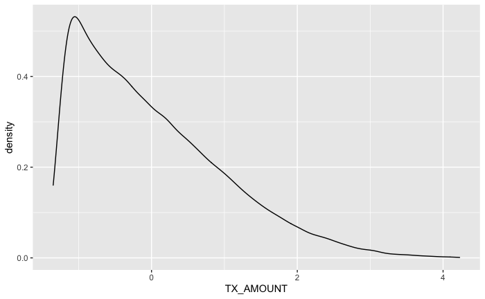

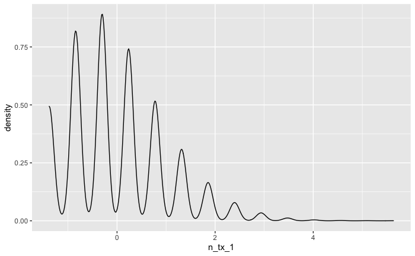

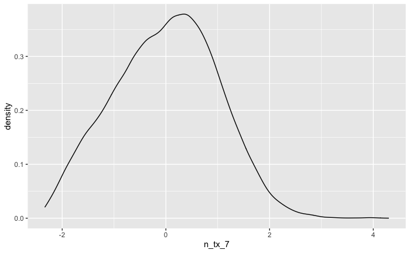

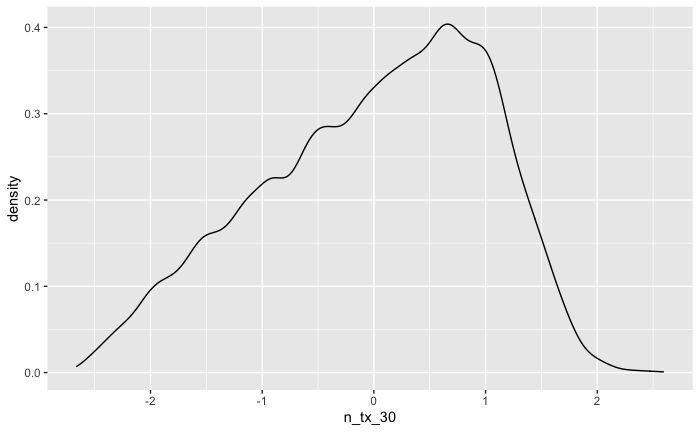

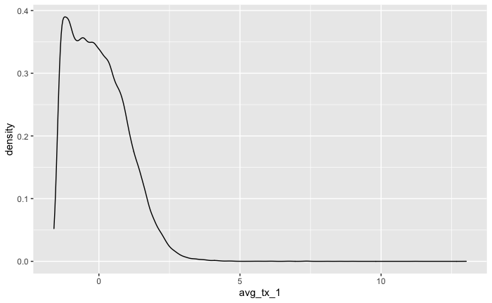

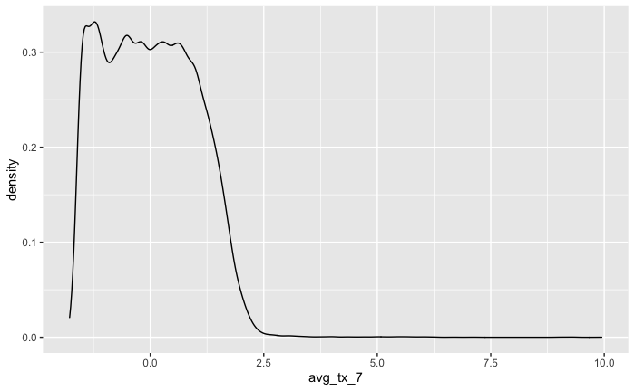

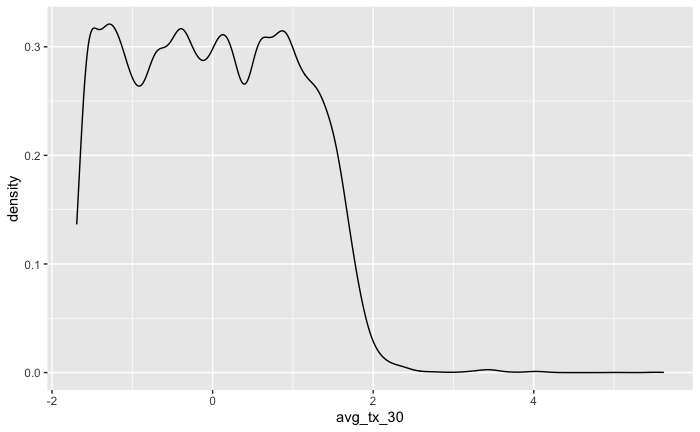

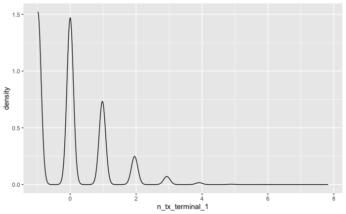

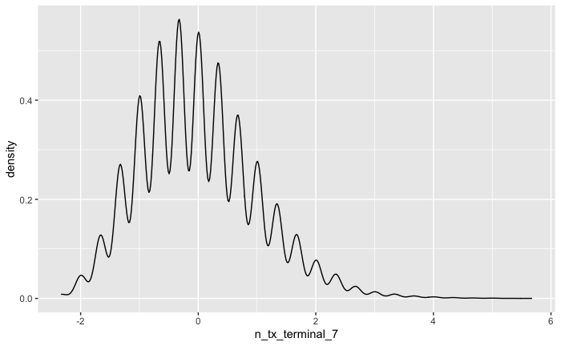

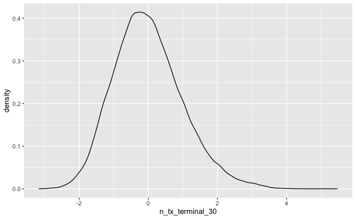

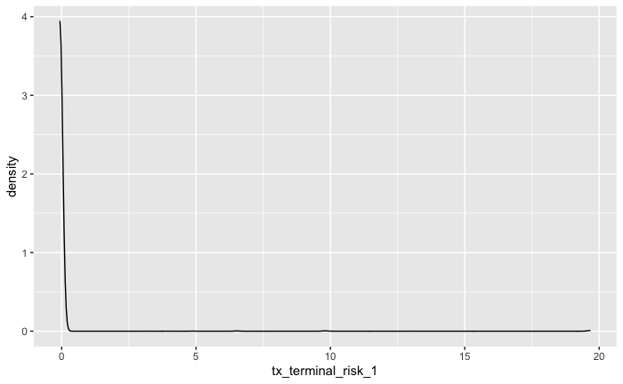

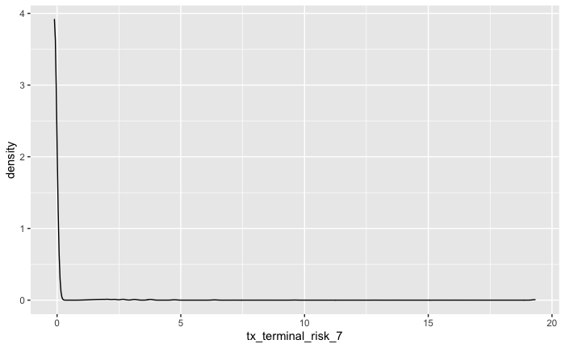

[1 more figures not shown]

```r
for (col in colnames(scaled_train)) {
  print(ggplot(data = scaled_train, mapping=aes_string(x=col)) + geom_density())
}
```

the distribution have a very bad shape, we need to apply some transformation, in order to run efficiently kmeans or mixture of gaussian

let’s try to apply a pca transformation

```r
pca = prcomp(scaled_train, scale=FALSE, center=FALSE)
pca_data_train = data.frame(predict(pca, newdata = scaled_train))
#pca_data_train = asin(sqrt((pca_data_train - min(pca_data_train)) / (max(pca_data_train) - min(pca_data_train))))
pca_data_train
```

|  | PC1 | PC2 | PC3 | PC4 | PC5 | PC6 | PC7 | PC8 | PC9 | PC10 | PC11 | PC12 | PC13 |
| --- | --- | --- | --- | --- | --- | --- | --- | --- | --- | --- | --- | --- | --- |
| 383221 | -1.4416840740 | 3.097900300 | 0.0497553212 | -1.060874814 | 1.612154195 | 0.2351946466 | 3.598330e-01 | -1.192365e-01 | 0.4071393677 | -5.342391e-03 | -0.1510842065 | -0.1181051460 | -0.2464183746 |
| 383222 | 1.0678707226 | 0.261556033 | 0.1765597412 | -2.227585099 | 1.443236017 | 0.1716351237 | 6.202155e-01 | 2.333074e-01 | 0.8646771884 | -8.623448e-03 | 0.3591863001 | 0.0155196872 | 0.0992405790 |
| 383223 | -1.8018749489 | -1.360449713 | 0.0569676372 | -1.512595597 | -0.200269877 | -0.0582601291 | 9.109160e-01 | 7.584670e-02 | 0.0802997152 | 3.305884e-02 | 0.0241321993 | 0.0047948829 | 0.0073997599 |
| 383224 | -0.9683577295 | -0.070710615 | 0.0661848381 | -1.500696457 | -0.344540936 | -0.0795482375 | -2.354880e-01 | 3.003923e-01 | -0.1670376913 | 2.322573e-02 | 0.0427239348 | 0.1987996579 | -0.0127532316 |
| 383225 | -1.1436320622 | 0.289279170 | 0.3671107116 | 1.237303913 | 0.677825044 | -0.4932330166 | -2.193138e-01 | -1.087623e+00 | 0.4896875775 | -7.370634e-01 | -0.3698750521 | -0.2018127038 | -0.1983929283 |
| 383226 | -2.5630303975 | -2.451688417 | -0.2522739595 | 0.300212616 | 1.059751969 | 0.1708721770 | 1.206680e-01 | 2.810042e-01 | -0.1910345091 | 1.278017e-02 | 0.0583631539 | 0.0563322097 | 0.0150540531 |
| 383227 | -0.7611879995 | 0.960828949 | 4.7530104307 | -3.835516653 | -0.859325202 | 4.8102325604 | 7.502828e-02 | -1.327779e+00 | -1.0522500292 | -9.795858e-01 | -0.1005030373 | -0.0155848745 | 0.0014234499 |
| 383228 | 2.2860622763 | 1.866817199 | 0.0820845092 | -1.568368718 | -0.598698575 | -0.1123689533 | -3.818375e-01 | -3.176411e-01 | -0.8370049371 | 3.603398e-02 | -0.1789630254 | -0.0283178470 | -0.1306580980 |
| 383229 | 0.1318298513 | -0.229052469 | -0.1797989884 | -0.034909110 | -1.181387866 | -0.1388553623 | -4.936666e-01 | -1.116029e+00 | -0.2069855281 | 3.973450e-02 | 0.2774420017 | 0.3671214685 | -0.0062722472 |
| 383230 | -0.9584237736 | 1.371286874 | -0.3641223363 | 1.302771306 | 0.067137742 | 0.0894603274 | 3.706054e-01 | -5.243836e-01 | -0.8564302399 | 3.410021e-02 | -0.3452539755 | -0.1269196104 | -0.0822916537 |

[output cut: 990 more lines]

```
[1] "PC1"
[1] "PC2"
[1] "PC3"
[1] "PC4"
[1] "PC5"
[1] "PC6"
[1] "PC7"
[1] "PC8"
[1] "PC9"
[1] "PC10"
[1] "PC11"
[1] "PC12"
[1] "PC13"
```

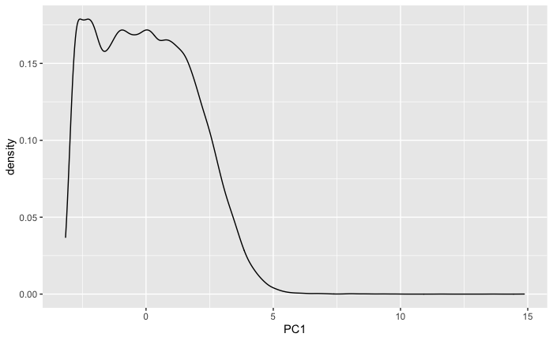

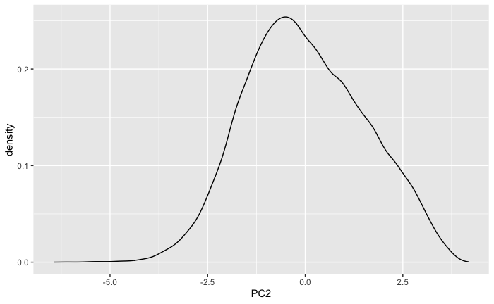

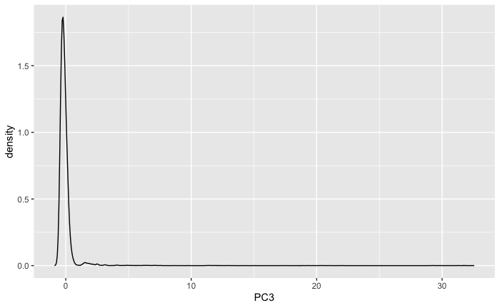

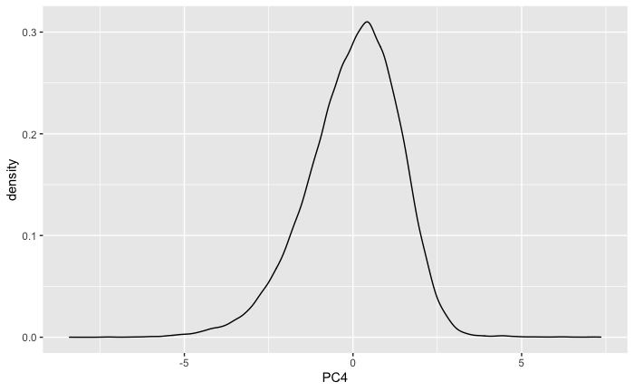

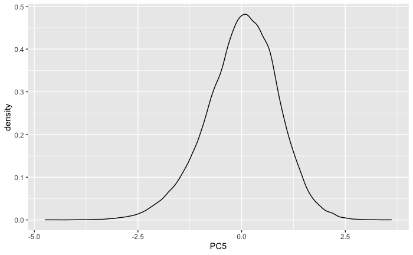

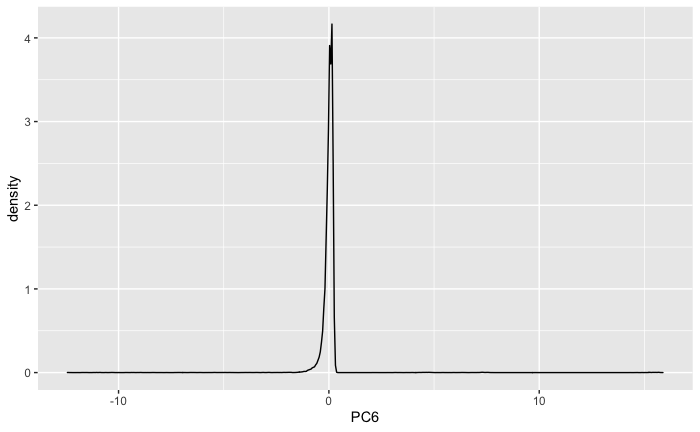

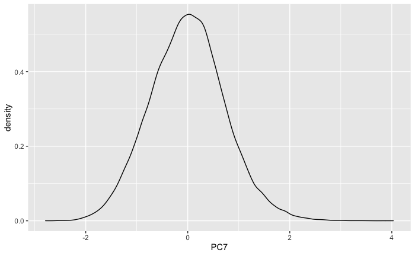

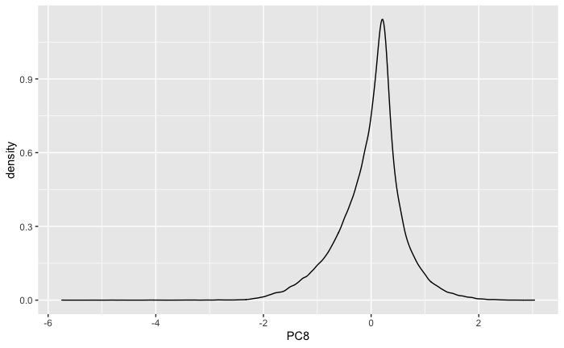

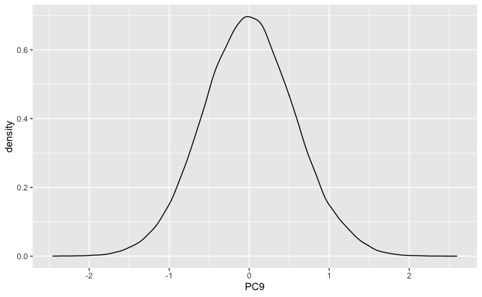

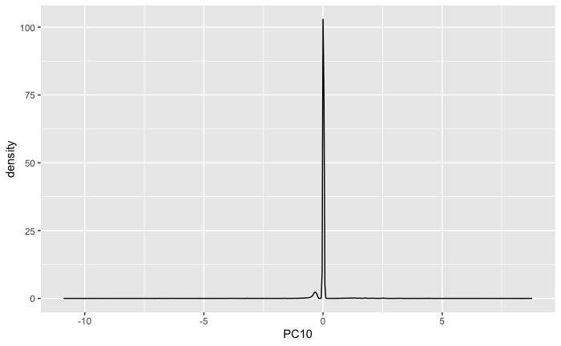

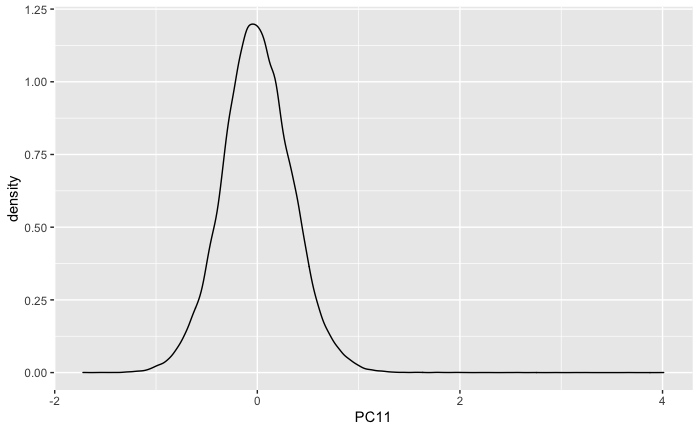

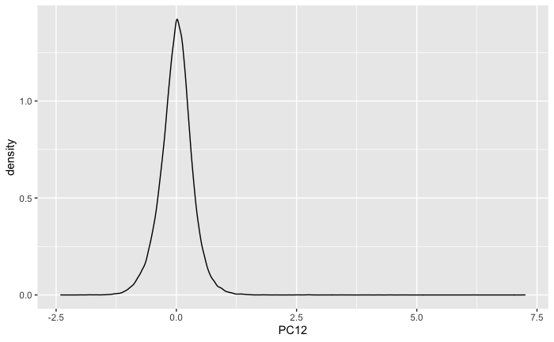

[1 more figures not shown]

```r
for (col in colnames(pca_data_train)) {
  print(col)
  print(ggplot(data = pca_data_train, mapping=aes_string(x=col)) + geom_density())
}
```

The trasfromed features now are a lot better.

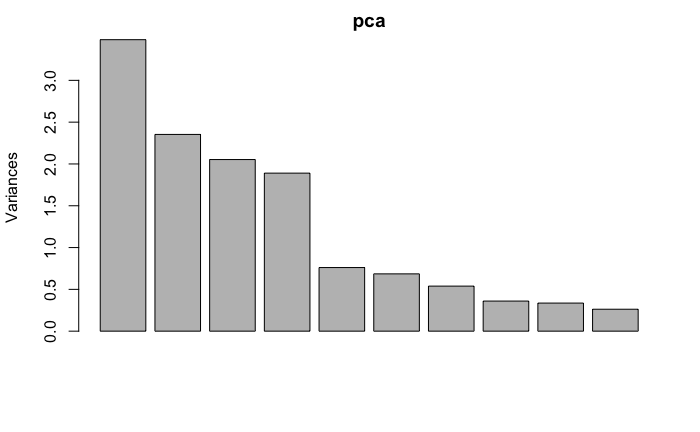

```r
screeplot(pca)
```

```r
summary(pca)
```

```
Importance of components:
                          PC1    PC2    PC3    PC4     PC5     PC6     PC7     PC8     PC9    PC10    PC11
Standard deviation     1.8672 1.5340 1.4327 1.3749 0.87231 0.82785 0.73409 0.59998 0.57963 0.51222 0.34697
Proportion of Variance 0.2682 0.1810 0.1579 0.1454 0.05853 0.05272 0.04145 0.02769 0.02584 0.02018 0.00926
Cumulative Proportion  0.2682 0.4492 0.6071 0.7525 0.81103 0.86375 0.90521 0.93290 0.95874 0.97892 0.98818
                          PC12    PC13
Standard deviation     0.34371 0.18837
Proportion of Variance 0.00909 0.00273
Cumulative Proportion  0.99727 1.00000
```

```r
pca_data_test = data.frame(predict(pca, newdata = scaled_test))
```

model based on distance work really well in lowd dimensional space, so we will keep only 3 number of compoents, this parameterr could be tuned.

```r
n_comp = 3
```

```r
# Modeling packages
library(cluster)     # for general clustering algorithms
library(factoextra)  # for visualizing cluster results
```

```r
cluster_data = pca_data_train[, 1:n_comp] %>% sample_n(1000)
cluster_data
```

|  | PC1 | PC2 | PC3 |
| --- | --- | --- | --- |
| 433674 | -2.7987036013 | 0.9336536358 | -0.284479070 |
| 386183 | -1.6903295525 | -1.2621622661 | -0.081035394 |
| 445908 | -1.7105257968 | -2.2076762445 | -0.217440708 |
| 425116 | -2.4544050700 | 0.4656977486 | -0.185864665 |
| 437097 | 0.8286145756 | 1.0807507654 | -0.332248653 |
| 432597 | 0.6192235162 | 0.6035858268 | -0.142661536 |
| 445611 | -0.6903976105 | 1.0797436097 | -0.304886096 |
| 383808 | -2.8021622579 | -2.3959875915 | -0.048444739 |
| 435640 | -1.2024231103 | 2.3811597410 | -0.213335196 |
| 399208 | 1.4122679221 | 0.2598738580 | 0.236938778 |

[output cut: 990 more lines]

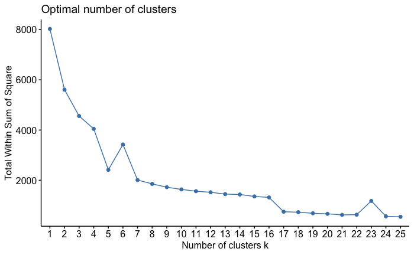

```r
fviz_nbclust(
  cluster_data,
  kmeans,
  k.max = 25,
  method = "wss",
  diss = get_dist(cluster_data, method = "euclidean")
)
```

```r
clustering <- kmeans(cluster_data[, 1:n_comp], centers = 5, nstart = 20)
```

```r
clustering$centers
```

```
        PC1        PC2         PC3
1  1.529655 -1.0937962 -0.02351734
2  1.930848  1.2992484 -0.03935488
3 -1.326664  1.3840705 -0.03643392
4  1.358842 -0.4768466 23.36545421
5 -1.480597 -1.2223452 -0.08829073
```

```r
center = as.matrix(clustering$centers)
min_distance = function(point) {
  diff = sweep(center, 2, point, "-") # subtract
  min(sqrt(rowSums(diff ^ 2, 2)))
}
```

```r
train_loss = sigmoid(apply(pca_data_train[,1:n_comp], 1, min_distance))
summary(train_loss)
```

```
   Min. 1st Qu.  Median    Mean 3rd Qu.    Max.
 0.5059  0.7072  0.7744  0.7680  0.8289  1.0000
```

```r
test_loss = sigmoid(apply(pca_data_test[,1:n_comp], 1, min_distance))
summary(test_loss)
```

```
   Min. 1st Qu.  Median    Mean 3rd Qu.    Max.
 0.5075  0.7070  0.7758  0.7690  0.8300  1.0000
```

normalize probability betwen 0 and 1 daily to compute the other measure: note normalization does not change the ordering

```r
full_test$p_hat = test_loss
p_top_k(full_test, 100, "TX_FRAUD", "p_hat", "TX_DATETIME")
```

```
[1] 0.3042857
```

```r
card_p_top_k(full_test,100, "TX_FRAUD", "p_hat", "CUSTOMER_ID", "TX_DATETIME")
```

```
[1] 0.3085714
```

```r
average_precision(full_test, target, p_hat, event_level="second")
```

| .metric | .estimator | .estimate |
| --- | --- | --- |
| average_precision | binary | 0.238898 |

# mixture of gaussian

```r
library(mclust)
```

```r
# Apply GMM model with 3 components
n_comp =3
sample_train = pca_data_train[,1:n_comp] %>% sample_n(1000)
mog <- densityMclust(sample_train, G=5:15)
```

```
fitting ...
```

```r
summary(mog)
```

```
-------------------------------------------------------
Density estimation via Gaussian finite mixture modeling
-------------------------------------------------------

Mclust VVI (diagonal, varying volume and shape) model with 5 components:
```

|  | log-likelihood | n | df | BIC | ICL |
| --- | --- | --- | --- | --- | --- |
|  | -3999.171 | 1000 | 34 | -8233.205 | -8712.54 |

```r
#apply(predict(mog, pca_data_train[, 1:n_comp], what="cdens"),1,max)
train_loss = 1-sigmoid(predict(mog, pca_data_train[, 1:n_comp], what="dens"))
summary(train_loss)
```

```
   Min. 1st Qu.  Median    Mean 3rd Qu.    Max.
 0.4714  0.4882  0.4932  0.4921  0.4971  0.5000
```

```r
#apply(predict(mog, pca_data_test[, 1:n_comp], what="cdens"),1,max)
test_loss = 1-sigmoid(predict(mog, pca_data_test[, 1:n_comp], what="dens"))
summary(test_loss)
```

```
   Min. 1st Qu.  Median    Mean 3rd Qu.    Max.
 0.4715  0.4883  0.4933  0.4923  0.4972  0.5000
```

```r
full_test$p_hat = test_loss
p_top_k(full_test,100,"TX_FRAUD","p_hat","TX_DATETIME")
```

```
[1] 0.3971429
```

```r
card_p_top_k(full_test,100, "TX_FRAUD", "p_hat", "CUSTOMER_ID", "TX_DATETIME")
```

```
[1] 0.3871429
```

```r
average_precision(full_test, target, p_hat, event_level = "second")
```

| .metric | .estimator | .estimate |
| --- | --- | --- |
| average_precision | binary | 0.3405647 |

by playing with the quantile i can decide many false positive alarm deal with.

```r
test_prediction = factor(as.numeric(test_loss >= quantile(train_loss, 0.98)), label=c("no","yes"))
test_true = full_test$target
confusionMatrix(test_prediction, test_true, mode="prec_recall", positive = "yes")
```

```
Confusion Matrix and Statistics

          Reference
Prediction    no   yes
       no  65307   215
       yes  1207   362

               Accuracy : 0.9788
                 95% CI : (0.9777, 0.9799)
    No Information Rate : 0.9914
    P-Value [Acc > NIR] : 1

                  Kappa : 0.3289

 Mcnemar's Test P-Value : <2e-16

              Precision : 0.230720
                 Recall : 0.627383
                     F1 : 0.337372
             Prevalence : 0.008600
         Detection Rate : 0.005396
   Detection Prevalence : 0.023386
      Balanced Accuracy : 0.804618

       'Positive' Class : yes
```

By using unsupervised method only very different transactions can be discovered and also we have a lot of problem with false positive. However we train the model using only 1000 observations and test using 67k observations.